# Optimal Treatment Analysis

## Outcome Variable

**Outcome Variable:** whz

## Predictor Variables

**Intervention Variable:** exclfeed6

**Adjustment Set:**

- arm
- sex
- brthmon
- W_mage
- meducyrs
- feducyrs
- hhwealth_quart
- hfoodsec
- W_mhtcm
- W_mwtkg
- W_mbmi
- vagbrth
- W_gagebrth
- W_birthwt
- W_birthlen
- W_nrooms
- W_nchldlt5
- month
- W_parity
- impfloor
- impsan
- safeh20
- delta_W_mage
- delta_meducyrs
- delta_feducyrs
- delta_hhwealth_quart
- delta_hfoodsec
- delta_W_mhtcm
- delta_W_mwtkg
- delta_W_mbmi
- delta_vagbrth
- delta_W_gagebrth
- delta_W_birthwt
- delta_W_birthlen
- delta_W_nrooms
- delta_W_nchldlt5
- delta_month
- delta_W_parity
- delta_impfloor
- delta_impsan
- delta_safeh20

## Stratifying Variables

The analysis was stratified on these variable(s):

- agecat
- studyid
- country

## Data Summary

| agecat | studyid | country | exclfeed6 | n_cell | n |
| --- | --- | --- | --- | --- | --- |
| Birth | ki0047075b-MAL-ED | BANGLADESH | 1 | 29 | 194 |
| Birth | ki0047075b-MAL-ED | BANGLADESH | 0 | 165 | 194 |
| Birth | ki0047075b-MAL-ED | BRAZIL | 1 | 1 | 57 |
| Birth | ki0047075b-MAL-ED | BRAZIL | 0 | 56 | 57 |
| Birth | ki0047075b-MAL-ED | INDIA | 1 | 1 | 37 |
| Birth | ki0047075b-MAL-ED | INDIA | 0 | 36 | 37 |
| Birth | ki0047075b-MAL-ED | NEPAL | 1 | 2 | 23 |
| Birth | ki0047075b-MAL-ED | NEPAL | 0 | 21 | 23 |
| Birth | ki0047075b-MAL-ED | PERU | 1 | 2 | 208 |
| Birth | ki0047075b-MAL-ED | PERU | 0 | 206 | 208 |
| Birth | ki0047075b-MAL-ED | SOUTH AFRICA | 1 | 0 | 90 |
| Birth | ki0047075b-MAL-ED | SOUTH AFRICA | 0 | 90 | 90 |
| Birth | ki0047075b-MAL-ED | TANZANIA, UNITED REPUBLIC OF | 1 | 0 | 105 |
| Birth | ki0047075b-MAL-ED | TANZANIA, UNITED REPUBLIC OF | 0 | 105 | 105 |
| Birth | ki1000108-CMC-V-BCS-2002 | INDIA | 1 | 7 | 7 |
| Birth | ki1000108-CMC-V-BCS-2002 | INDIA | 0 | 0 | 7 |
| Birth | ki1000108-IRC | INDIA | 1 | 0 | 12 |
| Birth | ki1000108-IRC | INDIA | 0 | 12 | 12 |
| Birth | ki1000109-EE | PAKISTAN | 1 | 24 | 28 |
| Birth | ki1000109-EE | PAKISTAN | 0 | 4 | 28 |
| Birth | ki1000304b-SAS-CompFeed | INDIA | 1 | 310 | 325 |
| Birth | ki1000304b-SAS-CompFeed | INDIA | 0 | 15 | 325 |
| Birth | ki1017093b-PROVIDE | BANGLADESH | 1 | 155 | 532 |
| Birth | ki1017093b-PROVIDE | BANGLADESH | 0 | 377 | 532 |
| Birth | ki1101329-Keneba | GAMBIA | 1 | 450 | 1327 |
| Birth | ki1101329-Keneba | GAMBIA | 0 | 877 | 1327 |
| Birth | ki1113344-GMS-Nepal | NEPAL | 1 | 390 | 522 |
| Birth | ki1113344-GMS-Nepal | NEPAL | 0 | 132 | 522 |
| Birth | kiGH5241-JiVitA-3 | BANGLADESH | 1 | 8381 | 10744 |
| Birth | kiGH5241-JiVitA-3 | BANGLADESH | 0 | 2363 | 10744 |

[output cut: 70 more lines]

The following strata were considered:

- agecat: 24 months, studyid: ki0047075b-MAL-ED, country: BANGLADESH
- agecat: 24 months, studyid: ki0047075b-MAL-ED, country: BRAZIL
- agecat: 24 months, studyid: ki0047075b-MAL-ED, country: INDIA
- agecat: 24 months, studyid: ki0047075b-MAL-ED, country: NEPAL
- agecat: 24 months, studyid: ki0047075b-MAL-ED, country: PERU
- agecat: 24 months, studyid: ki0047075b-MAL-ED, country: SOUTH AFRICA
- agecat: 24 months, studyid: ki0047075b-MAL-ED, country: TANZANIA, UNITED REPUBLIC OF
- agecat: 24 months, studyid: ki1000108-CMC-V-BCS-2002, country: INDIA
- agecat: 24 months, studyid: ki1000108-IRC, country: INDIA
- agecat: 24 months, studyid: ki1000109-EE, country: PAKISTAN
- agecat: 24 months, studyid: ki1017093b-PROVIDE, country: BANGLADESH
- agecat: 24 months, studyid: ki1101329-Keneba, country: GAMBIA
- agecat: 24 months, studyid: ki1113344-GMS-Nepal, country: NEPAL
- agecat: 24 months, studyid: ki1148112-LCNI-5, country: MALAWI
- agecat: 24 months, studyid: kiGH5241-JiVitA-3, country: BANGLADESH
- agecat: 24 months, studyid: kiGH5241-JiVitA-4, country: BANGLADESH
- agecat: 6 months, studyid: ki0047075b-MAL-ED, country: BANGLADESH
- agecat: 6 months, studyid: ki0047075b-MAL-ED, country: BRAZIL
- agecat: 6 months, studyid: ki0047075b-MAL-ED, country: INDIA
- agecat: 6 months, studyid: ki0047075b-MAL-ED, country: NEPAL
- agecat: 6 months, studyid: ki0047075b-MAL-ED, country: PERU
- agecat: 6 months, studyid: ki0047075b-MAL-ED, country: SOUTH AFRICA
- agecat: 6 months, studyid: ki0047075b-MAL-ED, country: TANZANIA, UNITED REPUBLIC OF
- agecat: 6 months, studyid: ki1000108-CMC-V-BCS-2002, country: INDIA
- agecat: 6 months, studyid: ki1000108-IRC, country: INDIA
- agecat: 6 months, studyid: ki1000109-EE, country: PAKISTAN
- agecat: 6 months, studyid: ki1000304b-SAS-CompFeed, country: INDIA
- agecat: 6 months, studyid: ki1000304b-SAS-FoodSuppl, country: INDIA
- agecat: 6 months, studyid: ki1017093b-PROVIDE, country: BANGLADESH
- agecat: 6 months, studyid: ki1101329-Keneba, country: GAMBIA
- agecat: 6 months, studyid: ki1113344-GMS-Nepal, country: NEPAL
- agecat: 6 months, studyid: ki1148112-LCNI-5, country: MALAWI
- agecat: 6 months, studyid: kiGH5241-JiVitA-3, country: BANGLADESH
- agecat: 6 months, studyid: kiGH5241-JiVitA-4, country: BANGLADESH
- agecat: Birth, studyid: ki0047075b-MAL-ED, country: BANGLADESH
- agecat: Birth, studyid: ki0047075b-MAL-ED, country: BRAZIL
- agecat: Birth, studyid: ki0047075b-MAL-ED, country: INDIA
- agecat: Birth, studyid: ki0047075b-MAL-ED, country: NEPAL
- agecat: Birth, studyid: ki0047075b-MAL-ED, country: PERU
- agecat: Birth, studyid: ki0047075b-MAL-ED, country: SOUTH AFRICA
- agecat: Birth, studyid: ki0047075b-MAL-ED, country: TANZANIA, UNITED REPUBLIC OF
- agecat: Birth, studyid: ki1000108-CMC-V-BCS-2002, country: INDIA
- agecat: Birth, studyid: ki1000108-IRC, country: INDIA
- agecat: Birth, studyid: ki1000109-EE, country: PAKISTAN
- agecat: Birth, studyid: ki1000304b-SAS-CompFeed, country: INDIA
- agecat: Birth, studyid: ki1017093b-PROVIDE, country: BANGLADESH
- agecat: Birth, studyid: ki1101329-Keneba, country: GAMBIA
- agecat: Birth, studyid: ki1113344-GMS-Nepal, country: NEPAL
- agecat: Birth, studyid: kiGH5241-JiVitA-3, country: BANGLADESH
- agecat: Birth, studyid: kiGH5241-JiVitA-4, country: BANGLADESH

### Dropped Strata

Some strata were dropped due to rare outcomes:

- agecat: Birth, studyid: ki0047075b-MAL-ED, country: BRAZIL
- agecat: Birth, studyid: ki0047075b-MAL-ED, country: INDIA
- agecat: Birth, studyid: ki0047075b-MAL-ED, country: NEPAL
- agecat: Birth, studyid: ki0047075b-MAL-ED, country: PERU
- agecat: Birth, studyid: ki0047075b-MAL-ED, country: SOUTH AFRICA
- agecat: Birth, studyid: ki0047075b-MAL-ED, country: TANZANIA, UNITED REPUBLIC OF
- agecat: Birth, studyid: ki1000108-CMC-V-BCS-2002, country: INDIA
- agecat: Birth, studyid: ki1000108-IRC, country: INDIA
- agecat: Birth, studyid: ki1000109-EE, country: PAKISTAN
- agecat: 6 months, studyid: ki0047075b-MAL-ED, country: INDIA
- agecat: 6 months, studyid: ki0047075b-MAL-ED, country: SOUTH AFRICA
- agecat: 6 months, studyid: ki0047075b-MAL-ED, country: TANZANIA, UNITED REPUBLIC OF
- agecat: 6 months, studyid: ki1000108-CMC-V-BCS-2002, country: INDIA
- agecat: 6 months, studyid: ki1000108-IRC, country: INDIA
- agecat: 6 months, studyid: ki1000304b-SAS-FoodSuppl, country: INDIA
- agecat: 24 months, studyid: ki0047075b-MAL-ED, country: INDIA
- agecat: 24 months, studyid: ki0047075b-MAL-ED, country: PERU
- agecat: 24 months, studyid: ki0047075b-MAL-ED, country: SOUTH AFRICA
- agecat: 24 months, studyid: ki0047075b-MAL-ED, country: TANZANIA, UNITED REPUBLIC OF
- agecat: 24 months, studyid: ki1000108-CMC-V-BCS-2002, country: INDIA
- agecat: 24 months, studyid: ki1000108-IRC, country: INDIA
- agecat: 24 months, studyid: ki1000109-EE, country: PAKISTAN

## Methods Detail

We’re interested in the causal parameters $E[Y_a]$ for all values of $a \in \mathcal{A}$. These parameters represent the mean outcome if, possibly contrary to fact, we intervened to set all units to have $A=a$. Under the randomization and positivity assumptions, these are identified by the statistical parameters $\psi_a=E_W[E_{Y|A,W}(Y|A=a,W)]$. In addition, we’re interested in the mean of $Y$, $E[Y]$ under no intervention (the observed mean). We will estimate these parameters by using SuperLearner to fit the relevant likelihood factors – $E_{Y|A,W}(Y|A=a,W)$ and $p(A=a|W)$, and then updating our likelihood fit using a joint TMLE.

For unadjusted analyses ($W=\{\}$), initial likelihoods were estimated using Lrnr_glm to estimate the simple $E(Y|A)$ and Lrnr_mean to estimate $p(A)$. For adjusted analyses, a small library containing Lrnr_glmnet, Lrnr_xgboost, and Lrnr_mean was used.

# Results Detail

## Results Plots

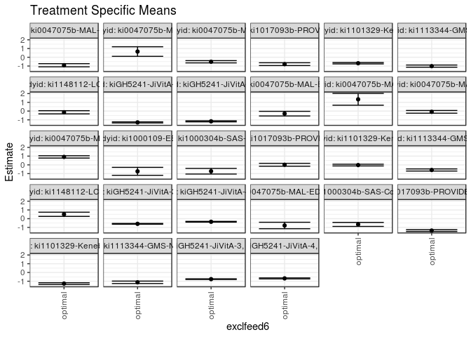

## Results Table

### Parameter: TSM

| agecat | studyid | country | intervention_level | baseline_level | estimate | ci_lower | ci_upper |
| --- | --- | --- | --- | --- | --- | --- | --- |
| Birth | ki0047075b-MAL-ED | BANGLADESH | optimal | observed | -0.7790103 | -1.1483743 | -0.4096464 |
| Birth | ki1000304b-SAS-CompFeed | INDIA | optimal | observed | -0.6562835 | -0.8852815 | -0.4272855 |
| Birth | ki1017093b-PROVIDE | BANGLADESH | optimal | observed | -1.3595399 | -1.4617107 | -1.2573691 |
| Birth | ki1101329-Keneba | GAMBIA | optimal | observed | -1.2722403 | -1.3706538 | -1.1738268 |
| Birth | ki1113344-GMS-Nepal | NEPAL | optimal | observed | -1.1235644 | -1.2620078 | -0.9851211 |
| Birth | kiGH5241-JiVitA-3 | BANGLADESH | optimal | observed | -0.7628029 | -0.8011415 | -0.7244642 |
| Birth | kiGH5241-JiVitA-4 | BANGLADESH | optimal | observed | -0.6760103 | -0.7309552 | -0.6210654 |
| 6 months | ki0047075b-MAL-ED | BANGLADESH | optimal | observed | -0.2934728 | -0.5580581 | -0.0288874 |
| 6 months | ki0047075b-MAL-ED | BRAZIL | optimal | observed | 1.3434957 | 0.6703247 | 2.0166668 |
| 6 months | ki0047075b-MAL-ED | NEPAL | optimal | observed | -0.0871609 | -0.2424011 | 0.0680792 |
| 6 months | ki0047075b-MAL-ED | PERU | optimal | observed | 0.9113307 | 0.7792285 | 1.0434330 |
| 6 months | ki1000109-EE | PAKISTAN | optimal | observed | -0.7393167 | -1.1924599 | -0.2861735 |
| 6 months | ki1000304b-SAS-CompFeed | INDIA | optimal | observed | -0.7249143 | -1.0477394 | -0.4020893 |
| 6 months | ki1017093b-PROVIDE | BANGLADESH | optimal | observed | 0.0116905 | -0.1534679 | 0.1768490 |
| 6 months | ki1101329-Keneba | GAMBIA | optimal | observed | -0.0230607 | -0.1211376 | 0.0750162 |
| 6 months | ki1113344-GMS-Nepal | NEPAL | optimal | observed | -0.5851865 | -0.7074614 | -0.4629115 |
| 6 months | ki1148112-LCNI-5 | MALAWI | optimal | observed | 0.5019796 | 0.2628933 | 0.7410658 |
| 6 months | kiGH5241-JiVitA-3 | BANGLADESH | optimal | observed | -0.5898484 | -0.6353978 | -0.5442990 |
| 6 months | kiGH5241-JiVitA-4 | BANGLADESH | optimal | observed | -0.3532244 | -0.3985077 | -0.3079410 |
| 24 months | ki0047075b-MAL-ED | BANGLADESH | optimal | observed | -0.9123947 | -1.0930897 | -0.7316997 |
| 24 months | ki0047075b-MAL-ED | BRAZIL | optimal | observed | 0.6541836 | 0.1063827 | 1.2019846 |
| 24 months | ki0047075b-MAL-ED | NEPAL | optimal | observed | -0.5120648 | -0.6404117 | -0.3837179 |
| 24 months | ki1017093b-PROVIDE | BANGLADESH | optimal | observed | -0.7868618 | -0.9481969 | -0.6255267 |
| 24 months | ki1101329-Keneba | GAMBIA | optimal | observed | -0.6812937 | -0.7608143 | -0.6017732 |
| 24 months | ki1113344-GMS-Nepal | NEPAL | optimal | observed | -1.0142418 | -1.1404626 | -0.8880210 |
| 24 months | ki1148112-LCNI-5 | MALAWI | optimal | observed | -0.1390921 | -0.3210454 | 0.0428612 |
| 24 months | kiGH5241-JiVitA-3 | BANGLADESH | optimal | observed | -1.2948899 | -1.3537373 | -1.2360425 |
| 24 months | kiGH5241-JiVitA-4 | BANGLADESH | optimal | observed | -1.1723195 | -1.2317205 | -1.1129185 |

### Parameter: E(Y)

| agecat | studyid | country | intervention_level | baseline_level | estimate | ci_lower | ci_upper |
| --- | --- | --- | --- | --- | --- | --- | --- |
| Birth | ki0047075b-MAL-ED | BANGLADESH | observed | observed | -0.9755670 | -1.1287016 | -0.8224325 |
| Birth | ki1000304b-SAS-CompFeed | INDIA | observed | observed | -0.6596308 | -0.9005716 | -0.4186900 |
| Birth | ki1017093b-PROVIDE | BANGLADESH | observed | observed | -1.2984586 | -1.3752758 | -1.2216415 |
| Birth | ki1101329-Keneba | GAMBIA | observed | observed | -1.2599925 | -1.3251703 | -1.1948146 |
| Birth | ki1113344-GMS-Nepal | NEPAL | observed | observed | -1.1064559 | -1.2034951 | -1.0094168 |
| Birth | kiGH5241-JiVitA-3 | BANGLADESH | observed | observed | -0.7807809 | -0.8030521 | -0.7585097 |
| Birth | kiGH5241-JiVitA-4 | BANGLADESH | observed | observed | -0.6904586 | -0.7435822 | -0.6373351 |
| 6 months | ki0047075b-MAL-ED | BANGLADESH | observed | observed | -0.1213203 | -0.2539388 | 0.0112981 |
| 6 months | ki0047075b-MAL-ED | BRAZIL | observed | observed | 0.9720774 | 0.8078144 | 1.1363403 |
| 6 months | ki0047075b-MAL-ED | NEPAL | observed | observed | 0.1091407 | -0.0265536 | 0.2448351 |
| 6 months | ki0047075b-MAL-ED | PERU | observed | observed | 1.0506150 | 0.9281868 | 1.1730433 |
| 6 months | ki1000109-EE | PAKISTAN | observed | observed | -0.6106944 | -0.9239621 | -0.2974268 |
| 6 months | ki1000304b-SAS-CompFeed | INDIA | observed | observed | -0.6348861 | -0.7630511 | -0.5067211 |
| 6 months | ki1017093b-PROVIDE | BANGLADESH | observed | observed | -0.1990907 | -0.2817968 | -0.1163845 |
| 6 months | ki1101329-Keneba | GAMBIA | observed | observed | -0.1997647 | -0.2531388 | -0.1463906 |
| 6 months | ki1113344-GMS-Nepal | NEPAL | observed | observed | -0.6009171 | -0.6886356 | -0.5131986 |
| 6 months | ki1148112-LCNI-5 | MALAWI | observed | observed | 0.3925000 | 0.2735307 | 0.5114693 |
| 6 months | kiGH5241-JiVitA-3 | BANGLADESH | observed | observed | -0.6001300 | -0.6240378 | -0.5762223 |
| 6 months | kiGH5241-JiVitA-4 | BANGLADESH | observed | observed | -0.3968456 | -0.4358721 | -0.3578192 |
| 24 months | ki0047075b-MAL-ED | BANGLADESH | observed | observed | -0.8169756 | -0.9388013 | -0.6951499 |
| 24 months | ki0047075b-MAL-ED | BRAZIL | observed | observed | 0.4626233 | 0.2567495 | 0.6684971 |
| 24 months | ki0047075b-MAL-ED | NEPAL | observed | observed | -0.3674429 | -0.4840752 | -0.2508107 |
| 24 months | ki1017093b-PROVIDE | BANGLADESH | observed | observed | -0.8928670 | -0.9755153 | -0.8102187 |
| 24 months | ki1101329-Keneba | GAMBIA | observed | observed | -0.8032329 | -0.8532842 | -0.7531817 |
| 24 months | ki1113344-GMS-Nepal | NEPAL | observed | observed | -1.1423525 | -1.2336321 | -1.0510729 |
| 24 months | ki1148112-LCNI-5 | MALAWI | observed | observed | -0.0770652 | -0.2204213 | 0.0662909 |
| 24 months | kiGH5241-JiVitA-3 | BANGLADESH | observed | observed | -1.3103375 | -1.3408810 | -1.2797940 |
| 24 months | kiGH5241-JiVitA-4 | BANGLADESH | observed | observed | -1.2265320 | -1.2620508 | -1.1910132 |

### Parameter: PAR

| agecat | studyid | country | intervention_level | baseline_level | estimate | ci_lower | ci_upper |
| --- | --- | --- | --- | --- | --- | --- | --- |
| Birth | ki0047075b-MAL-ED | BANGLADESH | optimal | observed | -0.1965567 | -0.5489562 | 0.1558429 |
| Birth | ki1000304b-SAS-CompFeed | INDIA | optimal | observed | -0.0033473 | -0.0446450 | 0.0379504 |
| Birth | ki1017093b-PROVIDE | BANGLADESH | optimal | observed | 0.0610813 | -0.0017752 | 0.1239378 |
| Birth | ki1101329-Keneba | GAMBIA | optimal | observed | 0.0122478 | -0.0624196 | 0.0869153 |
| Birth | ki1113344-GMS-Nepal | NEPAL | optimal | observed | 0.0171085 | -0.0825910 | 0.1168080 |
| Birth | kiGH5241-JiVitA-3 | BANGLADESH | optimal | observed | -0.0179780 | -0.0495800 | 0.0136240 |
| Birth | kiGH5241-JiVitA-4 | BANGLADESH | optimal | observed | -0.0144483 | -0.0416758 | 0.0127792 |
| 6 months | ki0047075b-MAL-ED | BANGLADESH | optimal | observed | 0.1721524 | -0.0735213 | 0.4178262 |
| 6 months | ki0047075b-MAL-ED | BRAZIL | optimal | observed | -0.3714184 | -1.0273921 | 0.2845553 |
| 6 months | ki0047075b-MAL-ED | NEPAL | optimal | observed | 0.1963017 | 0.0857679 | 0.3068354 |
| 6 months | ki0047075b-MAL-ED | PERU | optimal | observed | 0.1392843 | 0.0685855 | 0.2099831 |
| 6 months | ki1000109-EE | PAKISTAN | optimal | observed | 0.1286222 | -0.3610048 | 0.6182492 |
| 6 months | ki1000304b-SAS-CompFeed | INDIA | optimal | observed | 0.0900283 | -0.2741145 | 0.4541710 |
| 6 months | ki1017093b-PROVIDE | BANGLADESH | optimal | observed | -0.2107812 | -0.3563850 | -0.0651774 |
| 6 months | ki1101329-Keneba | GAMBIA | optimal | observed | -0.1767039 | -0.2572179 | -0.0961899 |
| 6 months | ki1113344-GMS-Nepal | NEPAL | optimal | observed | -0.0157307 | -0.0914466 | 0.0599853 |
| 6 months | ki1148112-LCNI-5 | MALAWI | optimal | observed | -0.1094796 | -0.3102218 | 0.0912626 |
| 6 months | kiGH5241-JiVitA-3 | BANGLADESH | optimal | observed | -0.0102816 | -0.0500832 | 0.0295199 |
| 6 months | kiGH5241-JiVitA-4 | BANGLADESH | optimal | observed | -0.0436213 | -0.0675515 | -0.0196910 |
| 24 months | ki0047075b-MAL-ED | BANGLADESH | optimal | observed | 0.0954191 | -0.0362633 | 0.2271015 |
| 24 months | ki0047075b-MAL-ED | BRAZIL | optimal | observed | -0.1915604 | -0.6756509 | 0.2925302 |
| 24 months | ki0047075b-MAL-ED | NEPAL | optimal | observed | 0.1446219 | 0.0686412 | 0.2206026 |
| 24 months | ki1017093b-PROVIDE | BANGLADESH | optimal | observed | -0.1060052 | -0.2468032 | 0.0347928 |
| 24 months | ki1101329-Keneba | GAMBIA | optimal | observed | -0.1219392 | -0.1852083 | -0.0586701 |
| 24 months | ki1113344-GMS-Nepal | NEPAL | optimal | observed | -0.1281107 | -0.2208602 | -0.0353612 |
| 24 months | ki1148112-LCNI-5 | MALAWI | optimal | observed | 0.0620269 | -0.0453583 | 0.1694120 |
| 24 months | kiGH5241-JiVitA-3 | BANGLADESH | optimal | observed | -0.0154476 | -0.0655252 | 0.0346300 |
| 24 months | kiGH5241-JiVitA-4 | BANGLADESH | optimal | observed | -0.0542125 | -0.1002211 | -0.0082040 |